# AA_SELECTIONS

## SELCTION SORT

Selection Sort adalah algoritma sorting yang mencari nilai terkecil dalam sebuah array lalu memindahkannya ke bagian depan array.

Selection Sort adalah algoritma sorting berbasis comparison. Algoritma ini bekerja dengan cara berulang kali memilih elemen terkecil (atau terbesar) dari bagian unsorted, lalu melakukan swap dengan elemen pertama yang belum terurut.

- Cari elemen terkecil dan swap dengan elemen pertama → elemen terkecil berada di posisi yang benar.
- Kemudian cari elemen terkecil berikutnya (dari sisa elemen) dan swap dengan elemen kedua.
- Proses ini terus dilakukan sampai semua elemen berada di posisi yang benar.

Sebelum di Selection Sort:

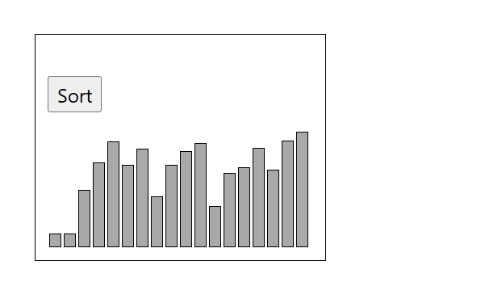

Sesudah di Selection Sort:

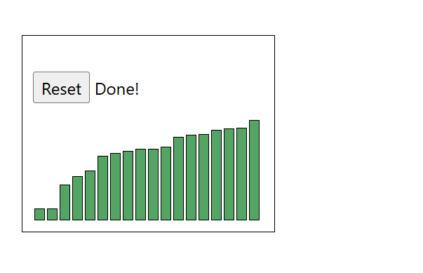

Algoritma ini akan terus menelusuri array berulang kali, memindahkan nilai terkecil berikutnya ke depan, sampai seluruh array terurut.

Cara Kerja:

1. Telusuri array untuk menemukan nilai terkecil.
2. Pindahkan nilai terkecil ke bagian depan dari bagian unsorted pada array.
3. Ulangi proses ini sebanyak jumlah elemen dalam array.

### Manual Run Through

Sebelum mengimplementasikan Selection Sort dalam program Python, kita coba secara manual.

Langkah 1: Mulai dari unsorted array.

```
[7, 12, 9, 11, 3]
```

Langkah 2: Cari nilai terkecil → yaitu 3.

```
[7, 12, 9, 11, 3]
```

Langkah 3: Pindahkan 3 ke depan.

```
[3, 7, 12, 9, 11]
```

Langkah 4: Periksa sisa array, mulai dari 7. 7 sudah paling kecil → tidak perlu dipindah.

```
[3, 7, 12, 9, 11]
```

Langkah 5: Cari nilai terkecil dari 12, 9, 11 → yaitu 9.

```
[3, 7, 12, 9, 11]
```

Langkah 6: Pindahkan 9 ke depan.

```
[3, 7, 9, 12, 11]
```

Langkah 7: Bandingkan 12 dan 11 → nilai terkecil adalah 11.

```
[3, 7, 9, 12, 11]
```

Langkah 8: Pindahkan ke depan.

```
[3, 7, 9, 11, 12]
```

Akhirnya, array sudah terurut.

Jalankan simulasi di bawah ini untuk melihat animasi langkah-langkah di atas

Sebelum diurutkan:

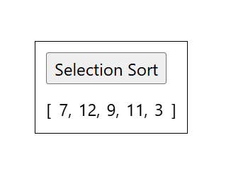

Sesudah diurutkan:

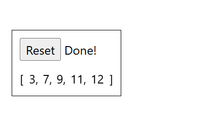

### Ciri-Ciri Selection Sort

1. Mencari Nilai Minimum atau Maksimum

Selection Sort mencari nilai terkecil atau terbesar dalam setiap iterasi.

2. Swap Dilakukan Sekali

Dalam satu iterasi hanya ada satu pertukaran.

3. Memiliki Dua Perulangan

Menggunakan:

- Perulangan luar
- Perulangan dalam
4. Lebih Sedikit Swap

Lebih hemat pertukaran dibanding Bubble Sort.

### Struktur Dasar Selection Sort

Selection Sort terdiri dari:

- Menentukan posisi awal
- Mencari nilai minimum
- Menukar posisi

### Implement Selection Sort dalam Python

Untuk mengimplementasikan Selection Sort dalam Python, kita membutuhkan:

1. Sebuah array berisi nilai.
2. Inner loop untuk mencari nilai terkecil dan memindahkannya ke depan.
3. Outer loop yang berjalan sebanyak n−1 kali.

Kode yang dihasilkan terlihat seperti ini:

Contoh

Penggunaan Selection Sort di Python List:

```python
mylist = [64, 34, 25, 5, 22, 11, 90, 12]

n = len(mylist)
for i in range(n-1):
  min_index = i
  for j in range(i+1, n):
     if mylist[j] < mylist[min_index]:
       min_index = j
  min_value = mylist.pop(min_index)
  mylist.insert(i, min_value)

print(mylist)
```

```
[5, 11, 12, 22, 25, 34, 64, 90]
```

Contoh lain penggunaan selection sort:

```python
def selection_sort(arr):
    n = len(arr)
    for i in range(n - 1):

        # Assume the current position holds
        # the minimum element
        min_idx = i

        # Iterate through the unsorted portion
        # to find the actual minimum
        for j in range(i + 1, n):
            if arr[j] < arr[min_idx]:

                # Update min_idx if a smaller element is found
                min_idx = j

        # Move minimum element to its
        # correct position
        arr[i], arr[min_idx] = arr[min_idx], arr[i]

def print_array(arr):
    for val in arr:
        print(val, end=" ")
    print()

if __name__ == "__main__":
    arr = [64, 25, 12, 22, 11]

    print("Original array: ", end="")
    print_array(arr)

    selection_sort(arr)

    print("Sorted array: ", end="")
    print_array(arr)
```

```
Original array: 64 25 12 22 11
Sorted array: 11 12 22 25 64
```

Selection Sort Shifting Problem

Algoritma Pengurutan Seleksi dapat ditingkatkan sedikit lagi.

Pada kode di atas, elemen nilai terendah dihilangkan, lalu disisipkan di depan array.

Setiap kali elemen array nilai terendah berikutnya dihapus, semua elemen berikut harus digeser satu tempat ke bawah untuk menggantikan penghapusan tersebut.

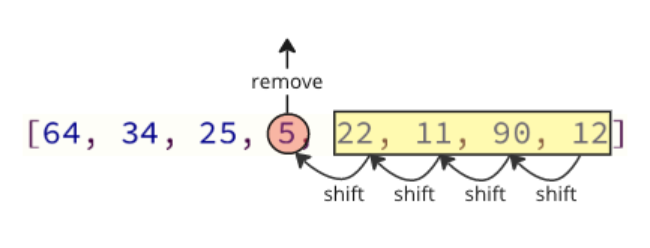

Operasi perpindahan ini memakan banyak waktu, dan kita bahkan belum selesai! Setelah nilai terendah (5) ditemukan dan dihapus, nilai tersebut disisipkan di awal array, menyebabkan semua nilai berikutnya bergeser satu posisi ke atas untuk memberi ruang bagi nilai baru, seperti yang ditunjukkan gambar di bawah.

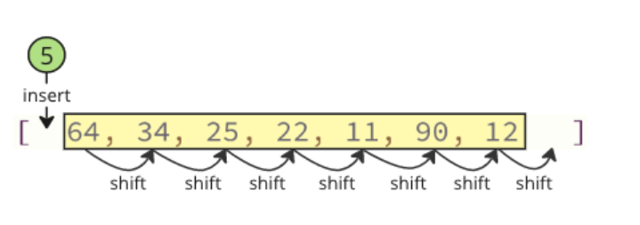

Catatan: Anda tidak akan melihat operasi perpindahan ini terjadi di kode jika Anda menggunakan bahasa pemrograman tingkat tinggi seperti Python atau Java, namun operasi perpindahan tersebut masih terjadi di latar belakang. Pengoperasian perpindahan seperti itu memerlukan waktu ekstra bagi komputer untuk menjalankannya, dan hal ini dapat menjadi masalah.

### Solusi: Swap Values

Daripada berpindah-pindah, tukar nilai terendah (5) dengan nilai pertama (64) seperti di bawah ini.

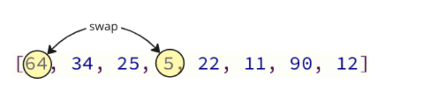

Kita dapat menukar nilai seperti yang ditunjukkan gambar di atas karena nilai terendah berakhir di posisi yang benar, dan tidak masalah di mana kita meletakkan nilai lain yang akan kita tukar, karena nilai tersebut belum diurutkan.

Berikut adalah simulasi yang menunjukkan cara kerja Pengurutan Seleksi dengan pertukaran yang ditingkatkan ini:

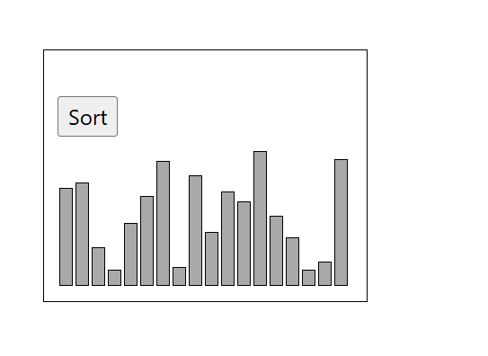

Kami akan memasukkan perbaikan dalam algoritma Pengurutan Seleksi:

Contoh

Algoritme Pengurutan Pilihan yang ditingkatkan, termasuk menukar nilai:

```python
mylist = [64, 34, 25, 12, 22, 11, 90, 5]

n = len(mylist)
for i in range(n):
  min_index = i
  for j in range(i+1, n):
     if mylist[j] < mylist[min_index]:
       min_index = j
  mylist[i], mylist[min_index] = mylist[min_index], mylist[i]

print(mylist)
```

```
[5, 11, 12, 22, 25, 34, 64, 90]
```

### Selection Sort Ascending

Ascending berarti dari kecil ke besar.

Contoh:

```
[1, 2, 3, 4, 5]
```

Kode:

```python
data = [9, 3, 7, 1]

for i in range(len(data)):

    minimum = i

    for j in range(i+1, len(data)):

        if data[j] < data[minimum]:
            minimum = j

    data[i], data[minimum] = data[minimum], data[i]

print(data)
```

```
[1, 3, 7, 9]
```

### Selection Sort Descending

Descending berarti dari besar ke kecil.

Contoh:

```
[9, 7, 5, 3, 1]
```

Kode:

```python
data = [9, 3, 7, 1]

for i in range(len(data)):

    maksimum = i

    for j in range(i+1, len(data)):

        if data[j] > data[maksimum]:
            maksimum = j

    data[i], data[maksimum] = data[maksimum], data[i]

print(data)
```

```
[9, 7, 3, 1]
```

### Selection Sort Time Complexity

1. Best Case

   O(n²)
2. Average Case

   O(n²)
3. Worst Case

   O(n²)

Selection Sort tetap melakukan pencarian minimum meskipun data sudah terurut.

Selection Sort mengurutkan sebuah array dengan n nilai.

Rata-rata, sekitar n/2 elemen dibandingkan untuk menemukan nilai terkecil dalam setiap loop.

Dan Selection Sort harus menjalankan loop untuk mencari nilai terkecil sekitar n kali.

Sehingga diperoleh: O(n/2 ⋅ n) = O(n²)

Grafik yang menunjukkan time complexity dari Selection Sort terlihat seperti ini:

Penjelasan lain:

Time Complexity: O(n²), karena terdapat dua nested loop:

- Satu loop untuk memilih elemen → O(n)
- Satu loop untuk membandingkan dengan elemen lain → O(n)
- Total: O(n) × O(n) = O(n²)

Auxiliary Space: O(1) Karena hanya menggunakan memory tambahan yang sangat kecil (variabel sementara).

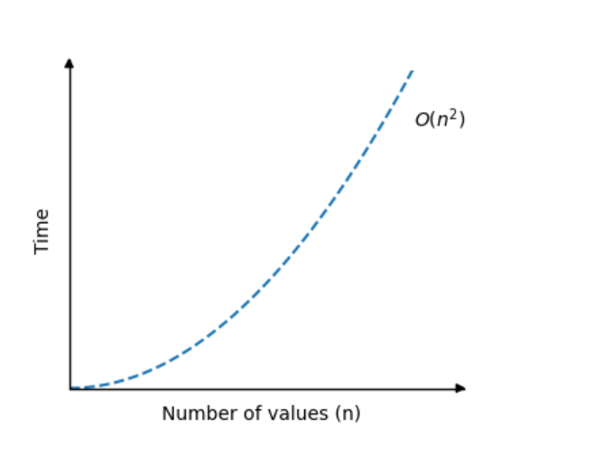

Seperti yang Anda lihat, waktu proses sama dengan Bubble Sort: Waktu proses meningkat sangat cepat ketika ukuran array diperbesar.

#### Advantages of Selection Sort

- Mudah dipahami dan diimplementasikan.
- Cocok untuk pembelajaran konsep dasar sorting.
- Hanya membutuhkan memory tambahan konstan O(1). Jumlah swap (atau memory writes) lebih sedikit dibanding banyak algoritma lain. Lebih efisien dalam kondisi di mana memory write mahal.

#### Disadvantages of Selection Sort

- Memiliki time complexity O(n²), sehingga lebih lambat dibanding algoritma seperti Quick Sort atau Merge Sort.
- Tidak bersifat stable, artinya urutan relatif elemen yang sama bisa berubah.

#### Applications of Selection Sort

- Cocok untuk pembelajaran dasar algoritma dan sorting.
- Digunakan untuk list kecil, terutama jika memory write mahal.
- Menjadi dasar dari algoritma lain seperti Heap Sort.

### Quiz GFG

1. Apakah Selection Sort merupakan algoritma pengurutan yang stabil?

   Tidak, Selection Sort tidak stabil karena dapat mengubah urutan relatif elemen yang sama.
2. Berapakah kompleksitas waktu dari Selection Sort?

   Algoritma Selection Sort memiliki kompleksitas waktu O(n^2) dalam kasus terbaik, rata-rata, dan terburuk.
3. Apakah Selection Sort membutuhkan memori tambahan?

   Tidak, Selection Sort adalah algoritma pengurutan in-place dan hanya membutuhkan ruang tambahan O(1).
4. Kapan waktu terbaik untuk menggunakan Selection Sort?

   Algoritma Selection Sort paling baik digunakan untuk dataset kecil, tujuan pendidikan, atau ketika penggunaan memori perlu diminimalkan.
5. Apa perbedaan antara Selection Sort dan Bubble Sort?

   Selection Sort memilih elemen minimum dan menempatkannya pada posisi yang tepat dengan lebih sedikit pertukaran, sedangkan Bubble Sort berulang kali menukar elemen yang berdekatan untuk mengurutkan array.